# Project 2, Phase 1

Magdalena Bogdańska, Piotr Obarski and Małgorzata Pujszo

Linear and Mixed Models with Examples for Biological and Medical Data

## Introduction

It has been observed that abnormalities in human dendritic spines can cause cognitive disorders such as ADHD, autism and intellectual disability. Thus it is believed that functionality of dendritic spines can influence brain cognitive functions. Based on the data on mice with different genomes and treated in different ways one can infer many hypothesis on the role of dendritic spines and affect of treatments.

## Objective

Our main goal is to find out which variables affect the length of dendritic spine. In the first phase we will verify whether the interaction between mice type and treatment’s type influences the length of dendritic spines.

## Preparing dataset

In this project we will use the dataset “dendriticSpines”, which contains data from three different studies. In this phase of the project we considered a subset with “chiron” study (named below as “dataset”).

Apart of studying “control group” (wild type with no genetic modifications) there were included two basic types of genetically modified mice.

Transgenic mouse (TG) is obtained through injection into a single cell of the mouse embryo, thus inserting new genetic information into the mouse genome or to over-express endogenous genes.

Knonckout mouse (KO) has inactivated an existing gene which has been done by modifying embryonic stem cells (replacing or disrupting selected gene with an artificial piece of DNA).

However in the study “chiron” KO mice don’t appear and consequently this type won’t be taken into account while modelling. We can observe it using the following command:

```r
table(dataset$mouse)
```

```
##
##   KO   TG   WT
##    0 6926 6028
```

Now, let’s verify which types of treatment are taken into acount in this study.

```r
table(dataset$treatment)
```

```
##
##      - chiron   dmso     gm     li
##      0   6158   6796      0      0
```

As we can see we have only two types of treatment which have nonzero observations: “chiron” and “dmso”. So, we focused on them only.

## Effect of interaction between treatment and mice type

### Graphical analysis

Since we are interested in the effect of interaction of type of mouse and type of treatment, let’s first see some plots and tables.

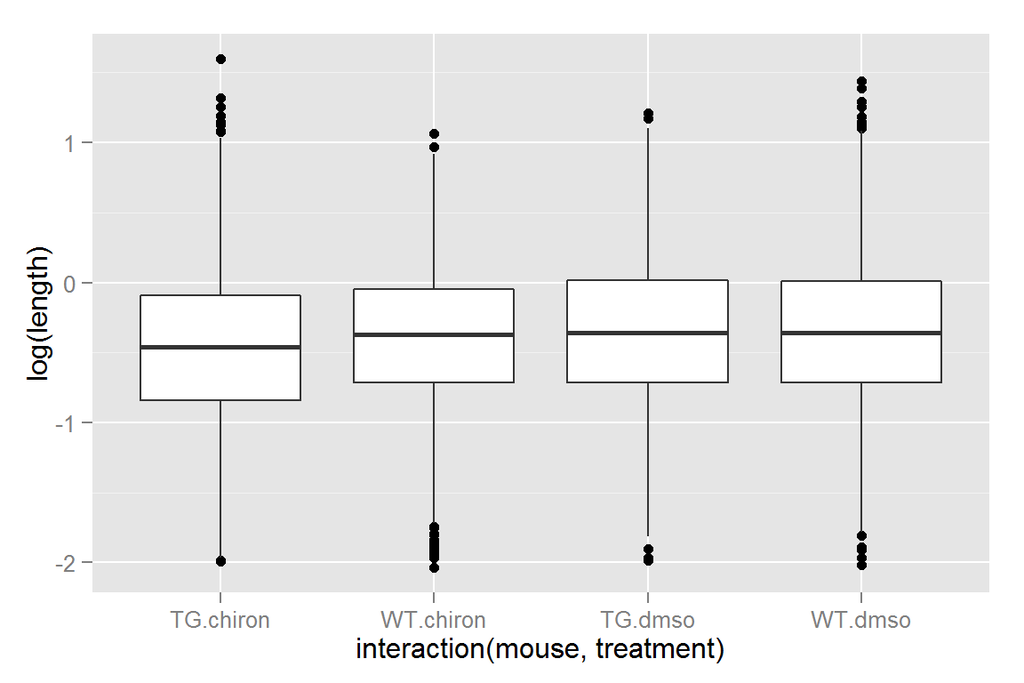

```r
ggplot(aes(y=log(length), x=interaction(mouse, treatment)), data=dataset) + geom_boxplot()
```

From boxplots, it looks as if there was no interaction. We calculated also means within groups. They are the following:

```r
by(dataset$length, dataset$mouse:dataset$treatment, mean)
```

```
## dataset$mouse:dataset$treatment: TG:chiron
## [1] 0.733856
## --------------------------------------------------------
## dataset$mouse:dataset$treatment: TG:dmso
## [1] 0.8027015
## --------------------------------------------------------
## dataset$mouse:dataset$treatment: WT:chiron
## [1] 0.7531081
## --------------------------------------------------------
## dataset$mouse:dataset$treatment: WT:dmso
## [1] 0.8118447
```

Here, one doesn’t notice a huge different. Let’s see also interaction plot.

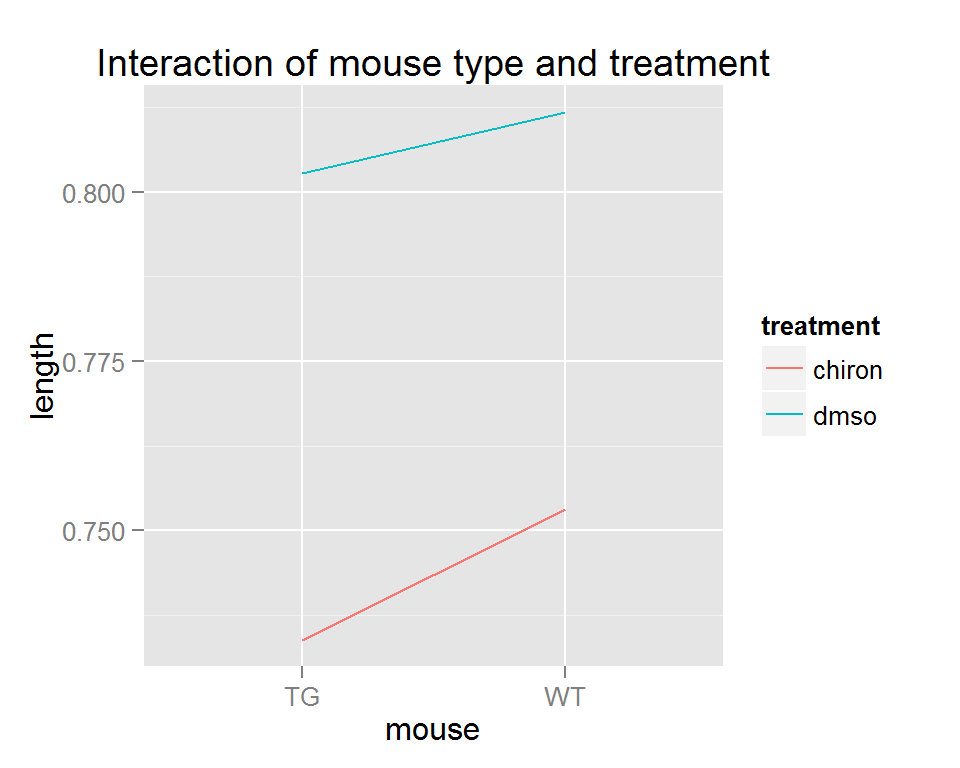

```r
ggplot(data=dataset, aes(x=mouse, y=length, group=treatment, colour=treatment)) + stat_summary(fun.y= mean, geom="line") +ggtitle("Interaction of mouse type and treatment")
```

Lines seems to be almost parallel and it is also a sign of the lack of interaction. Plots and table suggest that interaction is not important. However, we tested it in order to have more reliable results.

### Fitting a model

Since we have only 2 levels of type of mouse and 2 levels of type of treatment and we are interested in estimation of effects of these variables, we modeled them as fixed effects.

However, we also have an information of animals and photos of part of their brain and we probably have to take it into consideration. Because mice in the study are random sample from general population of mice and we are probably not interested of the effects of specific animal or photo, we modeled those variables as random effects.

Since we know that the effect of photo is nested in the effect of animal we tried the following model:

```r
model1 <- lmer(length ~ mouse*treatment + (1|Animal/Photo_ID_abs), data=dataset)
```

In order to have a proper model we need to check normality of random effects and normality of residuals.

First, let’s check normality of photo variable - it is done by performing Shapiro test.

```r
shapiro.test(as.matrix(ranef(model1)$`Photo_ID_abs:Animal`))
```

```
##
##  Shapiro-Wilk normality test
##
## data:  as.matrix(ranef(model1)$`Photo_ID_abs:Animal`)
## W = 0.9836, p-value = 0.08063
```

p-value is quite low but still at the level of 0.05 the test classify this variable as normal.

Normality of animal is tested here:

```r
shapiro.test(as.matrix(ranef(model1)$Animal))
```

```
##
##  Shapiro-Wilk normality test
##
## data:  as.matrix(ranef(model1)$Animal)
## W = 0.9868, p-value = 0.9911
```

The test is positive since the p-value is close to 1.

What is left is the normality of residuals. Because the number of observation is huge, we cannot perform Shapiro test. So, let’s look at it graphically.

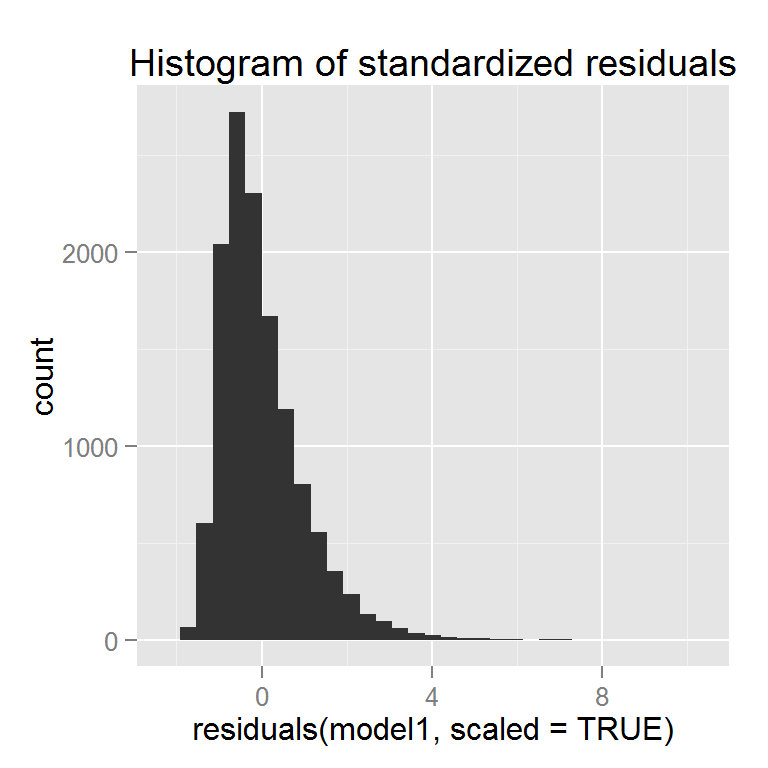

```r
qplot(residuals(model1, scaled=TRUE), geom="histogram") + ggtitle("Histogram of standardized residuals")
```

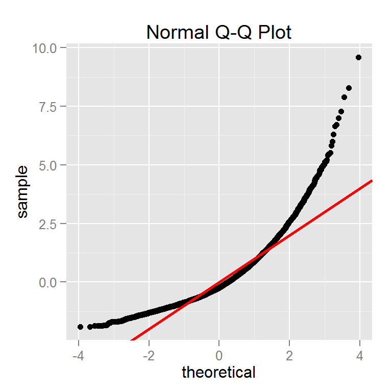

```r
qplot(sample = residuals(model1, scaled=TRUE), stat="qq") + geom_abline(intercept=0, slope=1, colour="red", size=1) + ggtitle("Normal Q-Q Plot")
```

Residuals doesn’t look normal. We tried to transform length variable in order to obtain normal residuals. We performed both: Box-Cox transformation anad Logtrans.

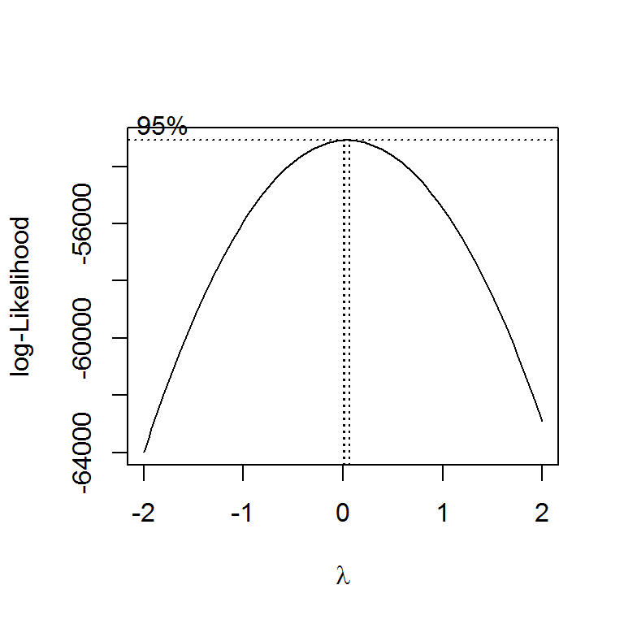

```r
boxcox(length~mouse*treatment +(1|Animal/Photo_ID_abs), data=dataset)
```

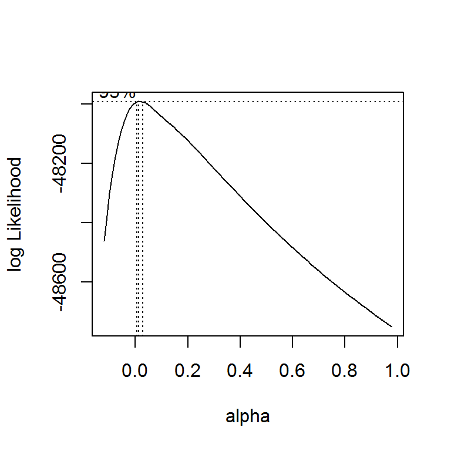

```r
logtrans(length~mouse*treatment +(1|Animal/Photo_ID_abs), data=dataset, alpha=seq(-min(dataset$length)+0.01,1,0.1))
```

As we can see both methods give approximately lambda=0, respectively alpha=0, so the best choice is just taking logarithm.

We performed the same tests for changed model and results are the following:

```r
model1 <- lmer(log(length) ~ mouse*treatment + (1|Animal/Photo_ID_abs), data=dataset)
summary(model1)
```

```
## Linear mixed model fit by REML ['lmerMod']
## Formula: log(length) ~ mouse * treatment + (1 | Animal/Photo_ID_abs)
##    Data: dataset
##
## REML criterion at convergence: 19747.3
##
## Scaled residuals:
##     Min      1Q  Median      3Q     Max
## -3.4156 -0.6895 -0.0108  0.6856  3.7132
##
## Random effects:
##  Groups              Name        Variance Std.Dev.
##  Photo_ID_abs:Animal (Intercept) 0.011799 0.10862
##  Animal              (Intercept) 0.007378 0.08589
##  Residual                        0.263634 0.51345
## Number of obs: 12954, groups:  Photo_ID_abs:Animal, 145; Animal, 10
##
## Fixed effects:
##                       Estimate Std. Error t value
## (Intercept)           -0.46038    0.04361 -10.557
## mouseWT                0.06501    0.06304   1.031
## treatmentdmso          0.11216    0.02827   3.967
## mouseWT:treatmentdmso -0.06327    0.04375  -1.446
##
## Correlation of Fixed Effects:
##             (Intr) mousWT trtmnt
## mouseWT     -0.692
## treatmntdms -0.346  0.239
## msWT:trtmnt  0.224 -0.374 -0.646
```

```r
shapiro.test(as.matrix(ranef(model1)$`Photo_ID_abs:Animal`))
```

```
##
##  Shapiro-Wilk normality test
##
## data:  as.matrix(ranef(model1)$`Photo_ID_abs:Animal`)
## W = 0.9957, p-value = 0.9477
```

```r
shapiro.test(as.matrix(ranef(model1)$Animal))
```

```
##
##  Shapiro-Wilk normality test
##
## data:  as.matrix(ranef(model1)$Animal)
## W = 0.9684, p-value = 0.876
```

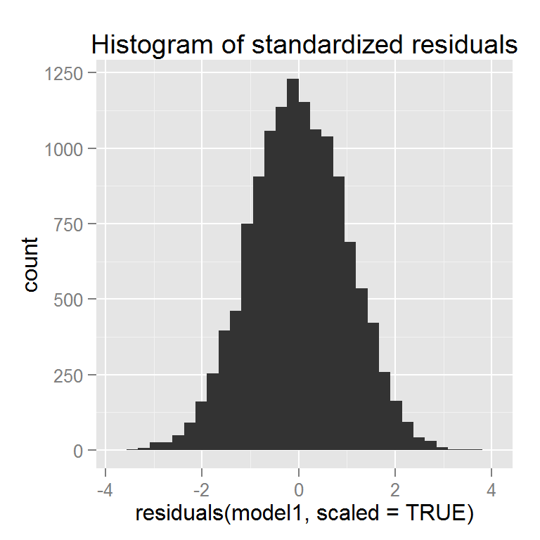

```r
qplot(residuals(model1, scaled=TRUE), geom="histogram") + ggtitle("Histogram of standardized residuals")
```

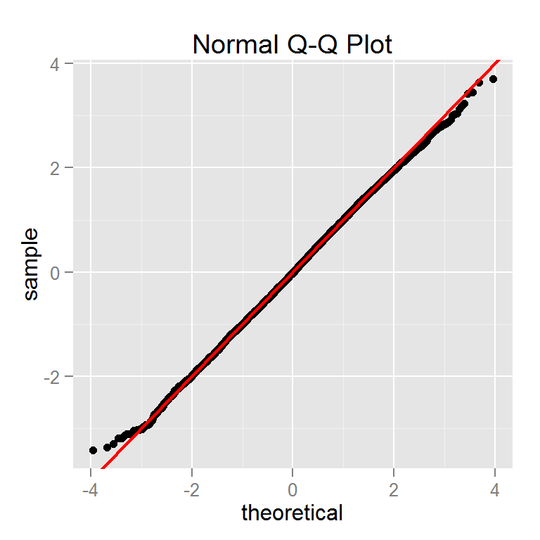

```r
qplot(sample = residuals(model1, scaled=TRUE), stat="qq") + geom_abline(intercept=0, slope=1, colour="red", size=0.75) + ggtitle("Normal Q-Q Plot")
```

In order to confirm results from Shapiro test, we plotted quantile plot with confidence intervals.

```
## $`Photo_ID_abs:Animal`
```

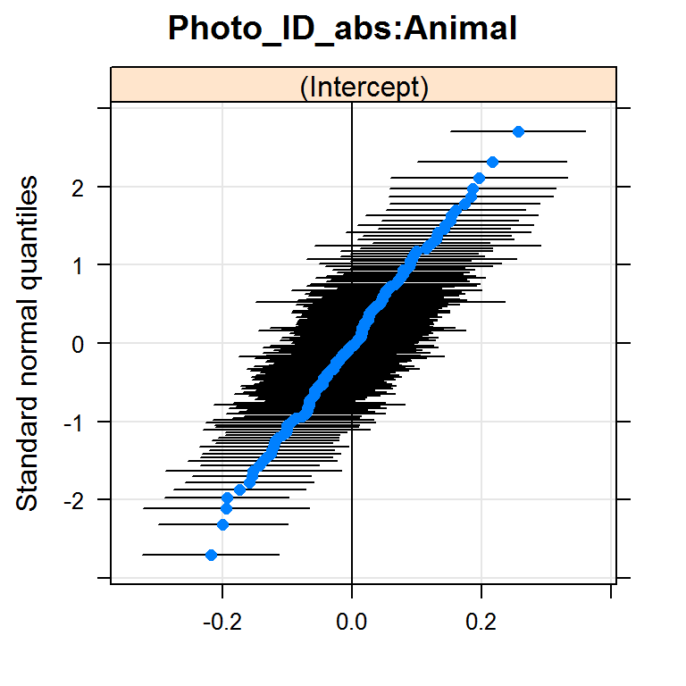

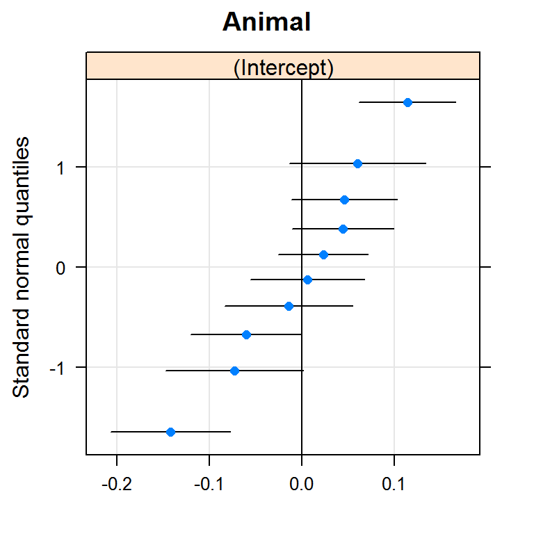

```r
qqmath(ranef(model1, condVar=TRUE))
```

Because it is possible to put a line which intersects all confidence intervals there is no reason to reject hypothesis of normality of random effects.

After transformation standardized residuals and random effects looks pretty normal so the assumptions all fullfilled.

### Testing variables coded as random effects

Now, we would like to find out whether we chose a good model. In order to do this, we tested all variables separately using Maximum Likelihood ratio test.

Random effect of animal:

```r
model2 <- lmer(log(length) ~ mouse*treatment + (1|Photo_ID_abs:Animal), data=dataset)
anova(model1, model2)
```

```
## refitting model(s) with ML (instead of REML)
```

```
## Data: dataset
## Models:
## model2: log(length) ~ mouse * treatment + (1 | Photo_ID_abs:Animal)
## model1: log(length) ~ mouse * treatment + (1 | Animal/Photo_ID_abs)
##        Df   AIC   BIC  logLik deviance  Chisq Chi Df Pr(>Chisq)
## model2  6 19765 19810 -9876.3    19753
## model1  7 19742 19794 -9863.9    19728 24.896      1   6.05e-07 ***
## ---
## Signif. codes:  0 '***' 0.001 '**' 0.01 '*' 0.05 '.' 0.1 ' ' 1
```

Effect of animal turned out to be very significant since p-value is low.

Let’s now test the nested effect of photo.

```r
model3 <- lmer(log(length) ~ mouse*treatment + (1|Animal), data=dataset)
anova(model1, model3)
```

```
## refitting model(s) with ML (instead of REML)
```

```
## Data: dataset
## Models:
## model3: log(length) ~ mouse * treatment + (1 | Animal)
## model1: log(length) ~ mouse * treatment + (1 | Animal/Photo_ID_abs)
##        Df   AIC   BIC   logLik deviance  Chisq Chi Df Pr(>Chisq)
## model3  6 20023 20068 -10005.4    20011
## model1  7 19742 19794  -9863.9    19728 283.09      1  < 2.2e-16 ***
## ---
## Signif. codes:  0 '***' 0.001 '**' 0.01 '*' 0.05 '.' 0.1 ' ' 1
```

Again, the effect is very important.

### Testing the effect of interaction

For now, we know that our random effects are significant. However, since our main goal was to check interaction effect, it’s time to find out something about its significance.

```r
model4 <- lmer(log(length) ~ mouse + treatment +(1|Animal/Photo_ID_abs), data=dataset)
anova(model1, model4)
```

```
## refitting model(s) with ML (instead of REML)
```

```
## Data: dataset
## Models:
## model4: log(length) ~ mouse + treatment + (1 | Animal/Photo_ID_abs)
## model1: log(length) ~ mouse * treatment + (1 | Animal/Photo_ID_abs)
##        Df   AIC   BIC  logLik deviance  Chisq Chi Df Pr(>Chisq)
## model4  6 19742 19787 -9864.9    19730
## model1  7 19742 19794 -9863.9    19728 2.0101      1     0.1563
```

Here the effect of interaction is non-significant. But let’s see if we obtain the same using t-test.

```r
int <- summary(model1)$coef[4,3]
2*pnorm(int, lower.tail=T)
```

```
## [1] 0.148139
```

Both tests reject the hypothesis of important influence of interaction on length of spine. Combining these results with the plots shown previously, we may infer that the effect of interaction of mouse and treatment variable is not significant in the model.

## Testing fixed effects

We have already tested the importance of random effects and of interaction (which was our main goal). However, we would like to know if the mouse and treatment variable are important.

Let’s test the effect of treatment first.

```r
model5 <- lmer(log(length) ~ mouse +(1|Animal/Photo_ID_abs), data=dataset)
anova(model4, model5)
```

```
## refitting model(s) with ML (instead of REML)
```

```
## Data: dataset
## Models:
## model5: log(length) ~ mouse + (1 | Animal/Photo_ID_abs)
## model4: log(length) ~ mouse + treatment + (1 | Animal/Photo_ID_abs)
##        Df   AIC   BIC  logLik deviance  Chisq Chi Df Pr(>Chisq)
## model5  5 19755 19792 -9872.5    19745
## model4  6 19742 19787 -9864.9    19730 15.299      1  9.178e-05 ***
## ---
## Signif. codes:  0 '***' 0.001 '**' 0.01 '*' 0.05 '.' 0.1 ' ' 1
```

The effect of treatment seems to be significant.

What about the effect of mouse?

```r
model6 <- lmer(log(length) ~ treatment +(1|Animal/Photo_ID_abs), data=dataset)
anova(model4, model6)
```

```
## refitting model(s) with ML (instead of REML)
```

```
## Data: dataset
## Models:
## model6: log(length) ~ treatment + (1 | Animal/Photo_ID_abs)
## model4: log(length) ~ mouse + treatment + (1 | Animal/Photo_ID_abs)
##        Df   AIC   BIC  logLik deviance  Chisq Chi Df Pr(>Chisq)
## model6  5 19740 19778 -9865.1    19730
## model4  6 19742 19787 -9864.9    19730 0.3543      1     0.5517
```

The effect of mouse turned out to be not important.

## Conclusions

We tested the effect of interactions and it turned out to be non-significant. We also found out that the effect of mouse is not important while the effect of treatment and random effects of animal and photo are. As a result, basing only on “chiron” study we may conclude that to explain length of spine we have to consider: treatment and the effects of particular animals and photos.